# Home team advantage in the NHL

Samrat Halder, Hariz Johnson, Jake Stamell

12/6/2019

## Project Overview

### Background and research questions

Home team advantage is a common phenomenon in sports. Intuitively, we expect a team to perform better in their home arena. They are used to that location, have their fans to support them, don’t need to travel to it, etc.

But what does it really mean to have an advantage? Looking below the level of wins and losses, what happens to teams when they are at home and away? Does their style of play change? Are there some places that are harder to play at than others? Are there teams that perform better when away compared to others?

For our project, we explored these questions for ice hockey games in the National Hockey League (NHL). In recent years, the NHL has started tracking where and when events (like shots and goals) happen during the game. This provides a new opportunity to explore the game differently. Not only can we examine high-level game information, but we can also look at play-level details like where events occur on the ice.

This project consists of the following report, which condenses and summarizes our findings. The first section provides a high-level overview of our project, while the second walks through the details of our analysis. We have also developed an interactive shiny app to allow the reader to explore different views of the data. The report primarily focuses on high level views, while the app gives the opportunity to explore more granular views of the data. We encourage the reader to peruse the app after reading through the report.

### What you need to know about hockey to understand this

Ice hockey is a sport where each team has 6 players: 5 skaters and 1 goalie. Teams play 3 periods, each taking 20 minutes. The team with the most goals at the end wins. On average, teams score 2-3 goals per game.

For reference, here are the main types of plays in hockey (these are the ones recorded by the NHL).

Offensive plays

- Goal: where one team scores
- Shot: where a team shoots the puck on goal
- Missed shot: where a team shoots the puck but misses the goal

Defensive

- Blocked shot: where a team shoots the puck, but the other team blocks it before it reaches the goal
- Takeaway: when a team takes the puck away from the other team
- Hit: when one player hits another (it’s allowed and all players wear protective gear!)

Other

- Penalty: where a foul is called on a team (following a penalty, that team plays with one less player for a short period of time)
- Giveaway: when a team loses the puck
- Faceoff: these events start a play and happen in 9 fixed locations on the ice (similar to a tip off in basketball)

For more information, check out the wikipedia page for ice hockey: https://en.wikipedia.org/wiki/Ice_hockey.

The NHL is the professional hockey league in the United States. It consists of 31 teams (30 before 2017) that each play 82 games per year. Each team plays half of their games at home and half at other teams’ arenas. (See the wikipedia page for more info: https://en.wikipedia.org/wiki/National_Hockey_League).

### Data collection

We gathered game data for all regular season games for the seasons in 2014-2018. This data consists of general information about the games (6232 total games) such as which teams played, who won, how many shots, where it was, etc. Additionally, we collected play-level data of each major event in the game. This includes the location, team, players, and more of each play in each game for events like goals, shots, penalties, etc. This is the primary data set for our project, consisting of (~1.6M events).

We collected our data directly from the NHL.com API, using the httr package to make requests and the jsonlite package to parse the raw json data. While there is no formal documentation for this API, there is an online community that has documented some of the available endpoints (https://gitlab.com/dword4/nhlapi). From there, we sifted through the information returned by these calls to find the information we were looking for.

To recreate this dataset, visit our github for the project and use script “2019-12-06_nhl-api-script.R”. The data itself is also directly available in the RData file “2019-12-07_nhl-cleaned-data.RData”.

### High level findings

In the NHL, ~55% of games are won by the home team. While the home team has a clear advantage, the degree of it varies by team. (Even if a really good team is playing away, they still are likely to be the better team.) Digging in to the play-level data, we see that home team advantage exists across almost all types of plays. Not only do teams shoot and score (and thus win) more when they are the home team, they also are penalized less. Perhaps fans yelling at the referee does have some effect!

Hardest places to play: Anaheim and Washington

Easiest places to play: Ottowa and Edmonton

Best teams when playing away: Carolina Hurricanes and New Jersey Devils

Worst teams when playing away: Pittsburgh Penguins and Calgary Flames

## Detailed report

### How big of an advantage do home teams have?

Overall, home teams have a significant advantage, winning ~55% of the time. This advantage has been consistent over the time period of this analysis.

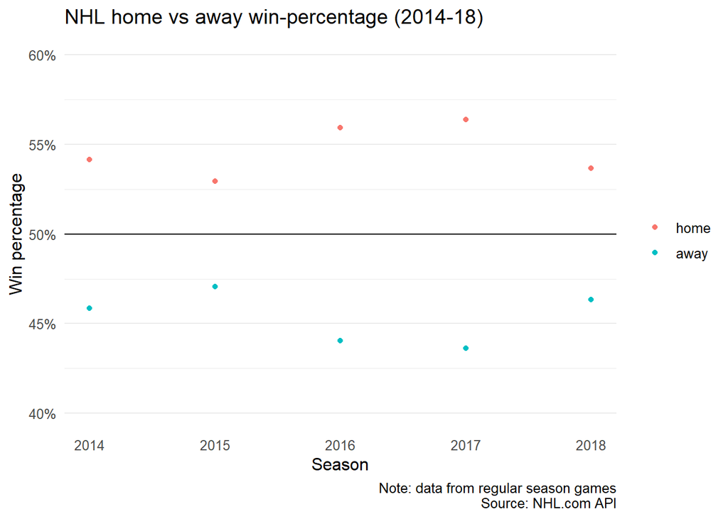

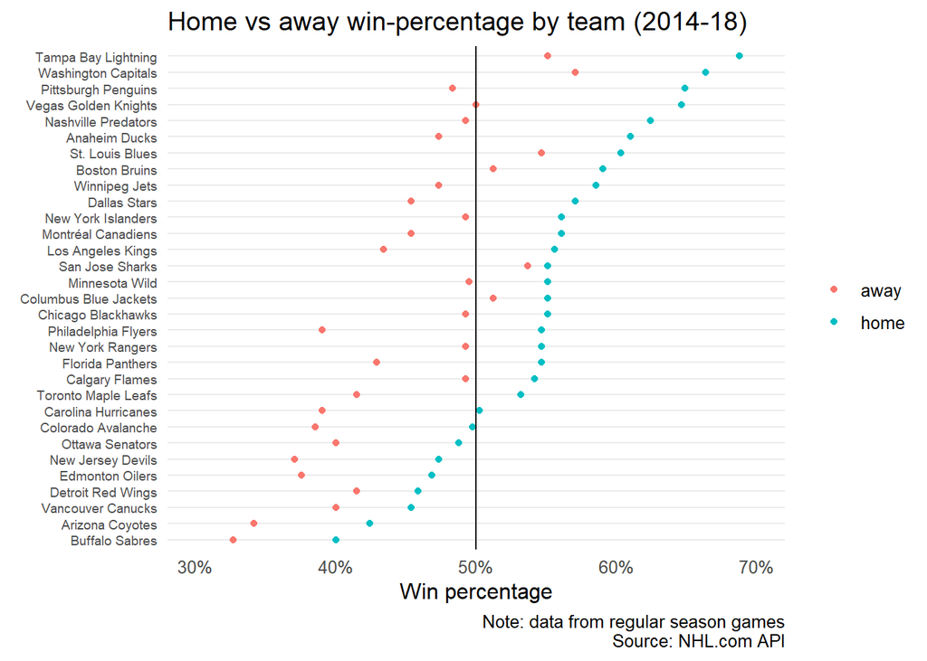

Clearly we need to account for this variation in team-strength. As we dig below the level of wins and losses, we will also explore metrics that adjust for this.

### What does home team advantage look like for different types of events?

A simple view of what percentage of plays are recorded for the home team highlights how the home team plays better. On the defensive side, home teams have more takeaways and hits. However, they block fewer shots, which could be explained by the fact that away teams shoot less. On the offensive side, home teams have a majority of the plays across all types.

And lastly, the other category is a little more interesting. Fewer penalties are called on the home team (in this case <50% is better for the home team). Perhaps referees are less inclined to call a penalty when the entire stadium is yelling at them for it. Additionally, home teams give away the puck much more than away teams.

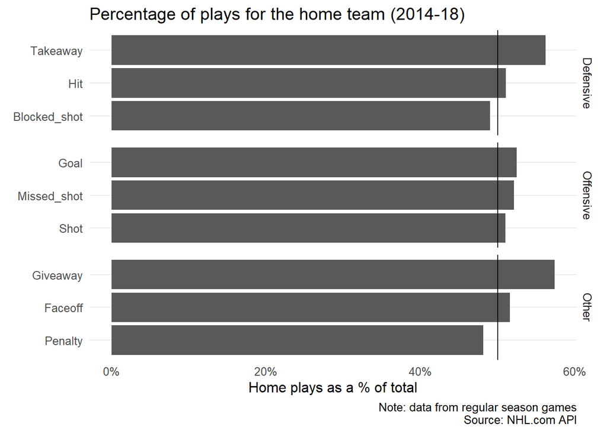

But what does this look like when accounting for team strength? The boxplots below show how teams perform at home compared to away for all play types. This metric is calculated as
$$\frac{\text{avg # plays when home per game} - \text{avg # plays when away per game}} {\text{avg # plays when away per game}}$$
This view provides a bit more nuance to the story. Some play types (like giveaways) have a large amount of variability as compared to goals, where all teams clearly perform better at home.

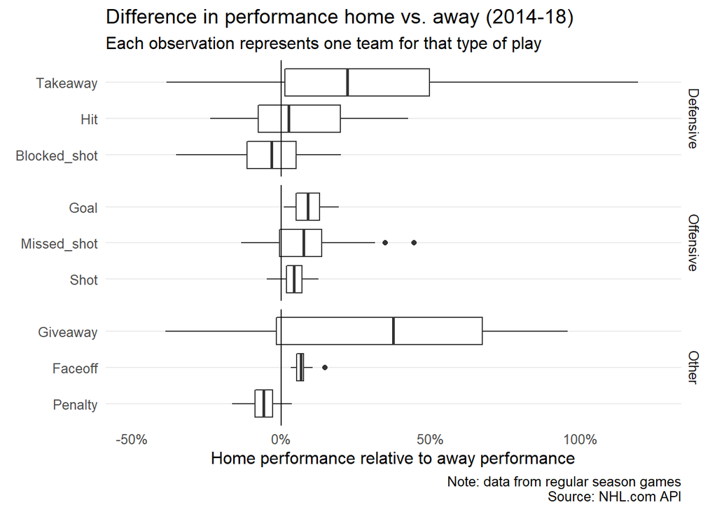

### What arenas are the hardest to play at?

To understand this question, we look at each arena and how other teams perform when they play there. We then compare this performance to that team’s average away performance. The three hardest places to play are Anaheim, Washington, and Montreal. Interestingly, in a recent poll of NHL players, Nashville, Winnipeg, and Pittsburgh were ranked as the toughest places to play. While these three are in the top half, they are certainly not in the top 5. On the other side of the coin, Ottawa and Edmonton are the easiest places to play. This is not surprising given that over this time period these teams did not perform well in general

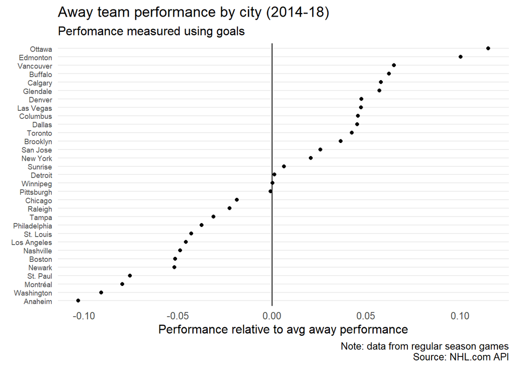

### What teams out-perform when on the road?

Earlier, we looked at win rates when teams are at home vs. away and noticed significant variation in the difference between home and away performance. We now look at this, using goals, while accounting for team strength. The Carolina Hurricanes, New Jersey Devils, and San Jose Sharks perform the best when away. Earlier we noticed the San Jose Sharks had a very small difference in home and away win percentage. But while the Carolina Hurricanes difference is small here, their home vs. away win percentage is much larger. (Of course, scoring goals is only half the battle in hockey!)

And on the other side, the Pittsburgh Penguins perform the worst when away. This is interesting because they were a really strong team over this time period. But their overall home/away win percentages do reflect this.

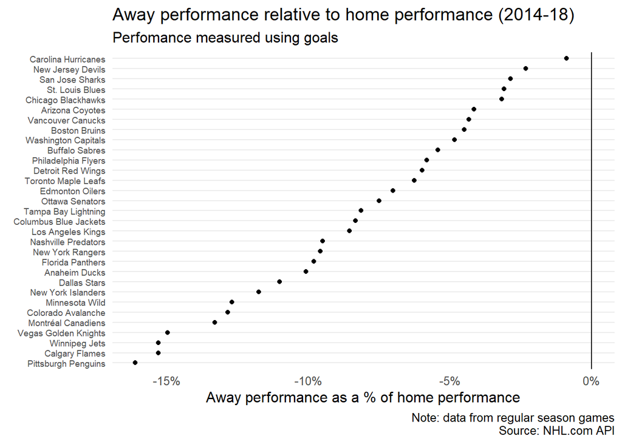